# EDA Executive Summary: Juiced Ball Era Offense

STAT 301-1 Data Science I

Hugo Belisario

December 13, 2019

# Data Import and Tidy Data

```r
library(tidyverse)

fangraphs <- read_csv("FanGraphs Leaderboard.csv")
baseball_savant <- read_csv("savant_data.csv")
fangraphs2 <- fangraphs %>%
  select(-playerid, -`2B`, -`3B`, -(`FB%_1`:`CHv`))

baseball_savant2 <- baseball_savant %>%
  select(-pitches, -player_id, -total_pitches, -pitch_percent, -(ba:woba), -hits, -abs, -(spin_rate:pos9_int_start_distance))
baseball_savant3 <- rename(baseball_savant2, Name = player_name)

(juiced_ball_era <- fangraphs2 %>%
  inner_join(baseball_savant3, by = "Name"))
```

```
## # A tibble: 292 x 37
##    Name   Team      H    HR   AVG `BB%` `K%`    OPS   ISO BABIP `LD%` `GB%`
##    <chr>  <chr> <dbl> <dbl> <dbl> <chr> <chr> <dbl> <dbl> <dbl> <chr> <chr>
##  1 Mike … Ange…   580   146 0.307 18.4… 19.7… 1.06  0.303 0.336 22.7… 33.7…
##  2 J.D. … - - -   635   146 0.312 10.5… 23.4… 0.985 0.288 0.357 21.4… 42.0…
##  3 Aaron… Yank…   387   110 0.273 16.1… 31.6… 0.952 0.285 0.357 23.4… 38.4…
##  4 Juan … Nati…   274    56 0.287 16.2… 20.0… 0.937 0.248 0.323 19.6… 46.8…
##  5 Chris… - - -   690   119 0.308 11.6… 20.4… 0.934 0.234 0.354 22.1… 52.1…
##  6 Fredd… Brav…   680   123 0.303 12.2… 20.1… 0.944 0.246 0.346 28.7… 35.1…
##  7 Charl… Rock…   764   127 0.315 7.7 % 17.6… 0.934 0.243 0.346 24.0… 39.5…
##  8 Nolan… Rock…   729   157 0.303 9.8 % 15.6… 0.947 0.271 0.309 19.9… 36.2…
##  9 Joey … Reds    640    92 0.299 16.3… 16.3… 0.91  0.194 0.333 26.6… 39.2…
## 10 Josh … - - -   464   115 0.269 15.2… 21.2… 0.918 0.263 0.295 19.8… 41.0…
## # … with 282 more rows, and 25 more variables: `FB%` <chr>, `HR/FB` <chr>,
## #   `Pull%` <chr>, `Cent%` <chr>, `Oppo%` <chr>, `Soft%` <chr>,
## #   `Med%` <chr>, `Hard%` <chr>, wFB <dbl>, wSL <dbl>, wCB <dbl>,
## #   wCH <dbl>, `wFB/C` <dbl>, `wSL/C` <dbl>, `wCB/C` <dbl>, `wCH/C` <dbl>,
## #   `wRC+` <dbl>, wOBA <dbl>, Bat <dbl>, WAR <dbl>, WPA <dbl>,
## #   xwoba <dbl>, xba <dbl>, launch_speed <dbl>, launch_angle <dbl>
```

# Most Interesting Aspect of the EDA

I am familiar with most of the variables that were used in the dataset. I had never done any analysis on Pitch Values which caught my eye when I was browsing FanGraphs prior to beginning this project. One of the initial questions I had about this particular group of players in this era was if hitters were having success against certain pitches. Pitch Values finds exactly that. There are two types of Pitch Values and since wFB/C corrects for the flaws included in the total runs by pitch by standardizing the values on a per 100 pitch basis. If you see a wFB/C of 1.50, you can generally say that hitter was successful against fastballs that year.

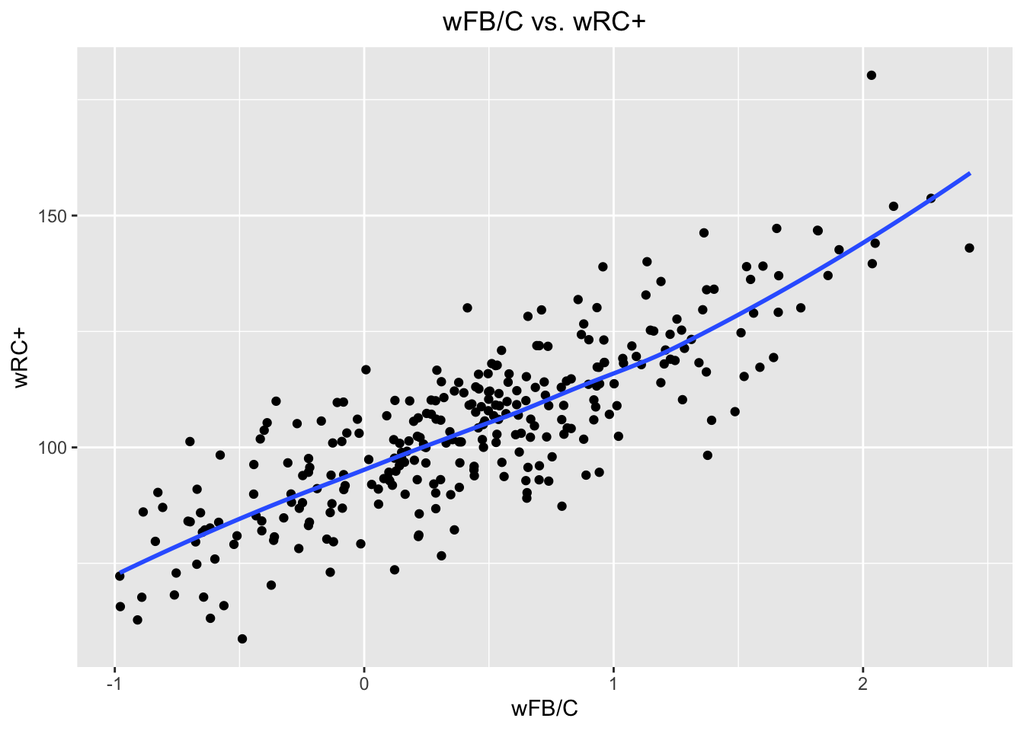

```r
ggplot(data = juiced_ball_era) +
  geom_jitter(mapping = aes(x = `wFB/C`, y = `wRC+`)) +
  geom_smooth(mapping = aes(x = `wFB/C`, y = `wRC+`), se = FALSE) +
  xlab("wFB/C") +
  ggtitle("wFB/C vs. wRC+") +
  theme(plot.title = element_text(hjust = 0.5))
```

In the case of success of against fastballs, one can safely say that hitting better against fastballs can increase your wRC+ as the rate statistic and Pitch Values have a positive relationship. Not shown here, but for other pitches there are players with -2 to -2.5 on the scale while for wFB/C it starts at -1 which means if you cannot hit the fastball at 1 point below the average or above you are most likely not good enough to stay in the major leagues.